# Course Project-Part 2

YYC

May 7, 2017

## Overview

The ToothGrowth data in the R datasets package will be analyzed

## Load the ToothGrowth data

```r
library(datasets)
a=ToothGrowth
```

## ToothGrowth data structure

```r
str(a)
```

```
## 'data.frame':    60 obs. of  3 variables:
##  $ len : num  4.2 11.5 7.3 5.8 6.4 10 11.2 11.2 5.2 7 ...
##  $ supp: Factor w/ 2 levels "OJ","VC": 2 2 2 2 2 2 2 2 2 2 ...
##  $ dose: num  0.5 0.5 0.5 0.5 0.5 0.5 0.5 0.5 0.5 0.5 ...
```

```r
#convert dose from num to factor
a$dose=as.factor(a$dose)
```

```r
str(a)
```

```
## 'data.frame':    60 obs. of  3 variables:
##  $ len : num  4.2 11.5 7.3 5.8 6.4 10 11.2 11.2 5.2 7 ...
##  $ supp: Factor w/ 2 levels "OJ","VC": 2 2 2 2 2 2 2 2 2 2 ...
##  $ dose: Factor w/ 3 levels "0.5","1","2": 1 1 1 1 1 1 1 1 1 1 ...
```

```r
head(a)
```

```
##    len supp dose
## 1  4.2   VC  0.5
## 2 11.5   VC  0.5
## 3  7.3   VC  0.5
## 4  5.8   VC  0.5
## 5  6.4   VC  0.5
## 6 10.0   VC  0.5
```

## A basic summary of the data

```r
summary(a)
```

```
##       len        supp     dose
##  Min.   : 4.20   OJ:30   0.5:20
##  1st Qu.:13.07   VC:30   1  :20
##  Median :19.25           2  :20
##  Mean   :18.81
##  3rd Qu.:25.27
##  Max.   :33.90
```

## Some basic exploratory data analyses

```r
#load ggplot2
library(ggplot2)
```

Visualize the tooth length vs. dose by supp (OJ and VC panels)

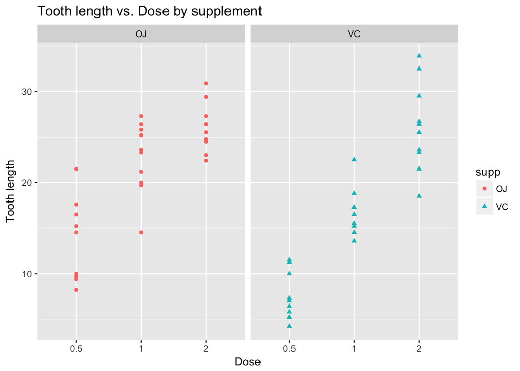

```r
ggplot(data=a,aes(x=dose,y=len))+geom_point(aes(shape=supp,col=supp))+facet_grid(.~supp)+xlab("Dose")+ylab("Tooth length")+ggtitle("Tooth length vs. Dose by supplement")
```

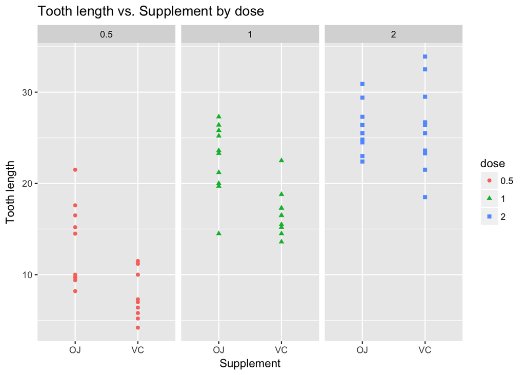

```r
ggplot(data=a,aes(x=supp,y=len))+geom_point(aes(shape=dose,col=dose))+facet_grid(.~dose)+xlab("Supplement")+ylab("Tooth length")+ggtitle("Tooth length vs. Supplement by dose")
```

## Use confidence intervals and/or hypothesis tests to compare tooth growth by supp and dose Hypothesis 1_Supplement methods are of no significant impact on tooth length

```r
t.test(len~supp,data=a)
```

```
##
##  Welch Two Sample t-test
##
## data:  len by supp
## t = 1.9153, df = 55.309, p-value = 0.06063
## alternative hypothesis: true difference in means is not equal to 0
## 95 percent confidence interval:
##  -0.1710156  7.5710156
## sample estimates:
## mean in group OJ mean in group VC
##         20.66333         16.96333
```

As the p-value > 0.05 and the confidence interval of the test contains zero, we can not reject the null hypotheiss. So it was concluded that the supplement methods probably have no impact on tooth length. Hypothesis 2_Dose are of no significant impact on tooth length

```r
t.test(a$len[a$dose==1],a$len[a$dose==0.5])
```

```
##
##  Welch Two Sample t-test
##
## data:  a$len[a$dose == 1] and a$len[a$dose == 0.5]
## t = 6.4766, df = 37.986, p-value = 1.268e-07
## alternative hypothesis: true difference in means is not equal to 0
## 95 percent confidence interval:
##   6.276219 11.983781
## sample estimates:
## mean of x mean of y
##    19.735    10.605
```

```r
t.test(a$len[a$dose==1],a$len[a$dose==2])
```

```
##
##  Welch Two Sample t-test
##
## data:  a$len[a$dose == 1] and a$len[a$dose == 2]
## t = -4.9005, df = 37.101, p-value = 1.906e-05
## alternative hypothesis: true difference in means is not equal to 0
## 95 percent confidence interval:
##  -8.996481 -3.733519
## sample estimates:
## mean of x mean of y
##    19.735    26.100
```

```r
t.test(a$len[a$dose==0.5],a$len[a$dose==2])
```

```
##
##  Welch Two Sample t-test
##
## data:  a$len[a$dose == 0.5] and a$len[a$dose == 2]
## t = -11.799, df = 36.883, p-value = 4.398e-14
## alternative hypothesis: true difference in means is not equal to 0
## 95 percent confidence interval:
##  -18.15617 -12.83383
## sample estimates:
## mean of x mean of y
##    10.605    26.100
```

As all the p-values < 0.05 and the confidence interval of the tests didn’t contain zero, we can reject the null hypotheiss. So it was concluded that the dose significantly impacted on tooth length.

## Conclusions&Assumption

Assumptions: The tooth of each observation was randomly assigned to each treatment and can represent the whole group. Conclusions: There is no evidence to prove the supplement methods have a significant impact on tooth length while the dose amounts (selected 0.5-2) does.